# GSB 544 Lab 4

Author

Eddie Cagney

## 1

# Data Prep

```python
import pandas as pd
from sklearn.metrics import mean_squared_error, r2_score
from sklearn.linear_model import LinearRegression
from sklearn.model_selection import train_test_split
lr = LinearRegression()

dat = pd.read_csv("https://www.dropbox.com/s/bocjjyo1ehr5auz/insurance_costs_1.csv?dl=1")
```

# Summary

```python
mean = dat['age'].mean()
print(f'The average age of the data is {mean}')

sex_prop = dat['sex'].value_counts(normalize=True)
print(f'The proportion of female-to-male is \n{sex_prop}')

charges_summary = dat['age'].describe()
print(f'A brief description of the charges variable: \n{charges_summary}')
```

[output not shown]

# Fixing Data

In the data, I noticed that the categorical variables are written as strings, not boolean values. So it would be best to convert these into dummy variables for analysis.

```python
from pandas import get_dummies
df = get_dummies(dat)
```

# Plots

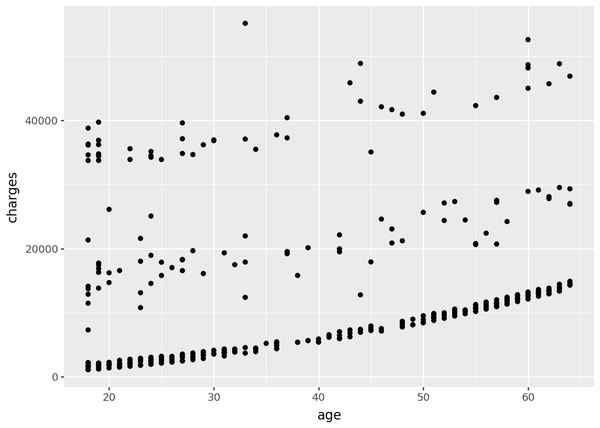

```python
from plotnine import *

(ggplot(df,
aes(x = 'age', y = 'charges'))
+ geom_point()
)
```

Some strange patterns appear in this plots with `charges` ran along `age`. Visually, it looks like there could be a categoircal variable that makes for certain “breaks” between the data in this graph.

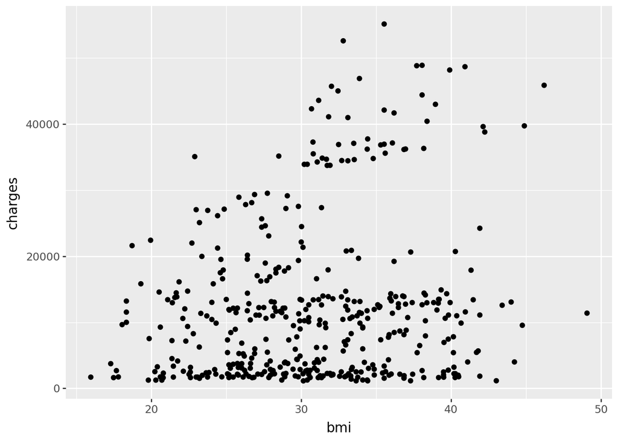

```python
(ggplot(df,
aes(x = 'bmi', y = 'charges'))
+ geom_point()
)
```

There still seems to be some srange collection of values in this plot, but not nearly as distinct as the previous plot. This leads me to believe this graph is also effected by the same variable as the previous plot.

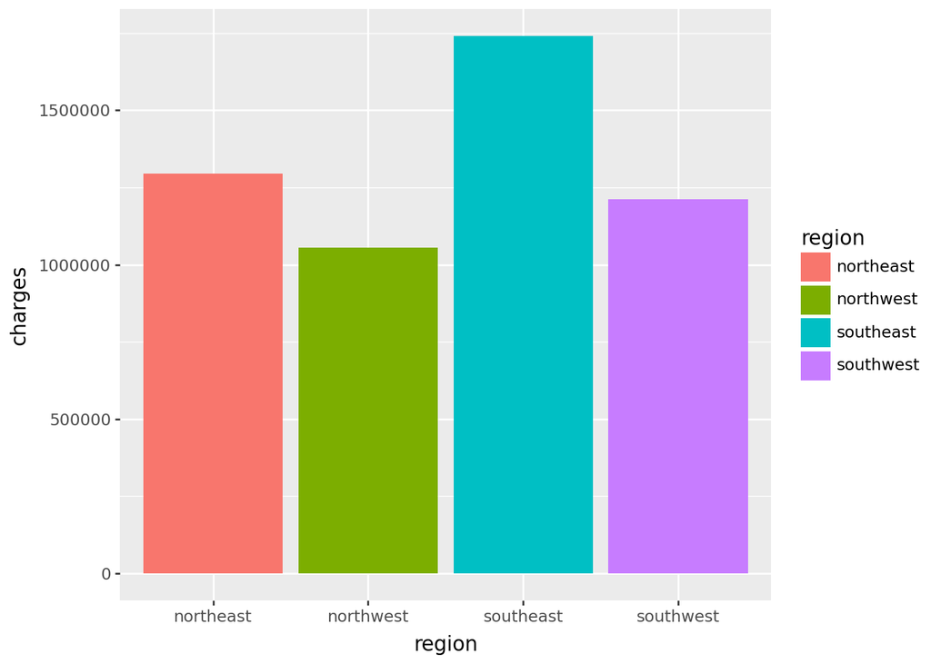

```python
(ggplot(dat,
aes(x = 'region', y = 'charges', fill = 'region'))
+ geom_col()
)
```

To further inspect, I plotted charges based on region and didn’t notice anything too bizzare so I’m assuming it will be within another categorical variable.

## 2

# Modeling

```python
y = df['charges']
X = df[['age']]

lr_fit = lr.fit(X, y)

coefs = lr_fit.coef_
inter = round(lr_fit.intercept_,2)
print(f'The coefficient estimate for age as a predictor of charges is {round(coefs[0],2)}, this model also gave the intercept of {inter}.')

X_train, X_test, y_train, y_test = train_test_split(X, y, test_size=0.25)
lr_fit = lr.fit(X_train, y_train)

y_pred_lrfit_test_age = lr_fit.predict(X_test)
mse_test_lrfit = mean_squared_error(y_test, y_pred_lrfit_test_age)

r2_test_lrfit = r2_score(y_test, y_pred_lrfit_test_age)

print(f'The MSE for the model including age is {round(mse_test_lrfit,2)} and the R-squared is {round(r2_test_lrfit,3)}.')
```

```
The coefficient estimate for age as a predictor of charges is 228.8, this model also gave the intercept of 3611.76.
The MSE for the model including age is 182038361.48 and the R-squared is -0.001.
```

```python
y2 = df['charges']
X2 = df[['age', 'sex_female']]

lr_fit2 = lr.fit(X2, y2)

coefs2 = lr_fit2.coef_
inter2 = round(lr_fit2.intercept_,2)
print(f'The coefficient estimate for age as a predictor of charges is {round(coefs2[0],2)}, our coefficient estimate for sex(female) is {round(coefs2[1],2)} this model also gave the intercept of {inter2}.')
```

```
The coefficient estimate for age as a predictor of charges is 228.43, our coefficient estimate for sex(female) is -649.83 this model also gave the intercept of 3965.16.
```

This model leads us to predict that females are typically charged less then men by insurance, adjusting for age.

```python
y3 = df['charges']
X3 = df[['age', 'smoker_yes']]

lr_fit3 = lr.fit(X3, y3)

coefs3 = lr_fit3.coef_
inter3 = round(lr_fit3.intercept_,2)
print(f'The coefficient estimate for age as a predictor of charges is {round(coefs3[0],2)}, our coefficient estimate for smoker(yes) is {round(coefs3[1],2)} this model also gave the intercept of {inter3}.')
```

```
The coefficient estimate for age as a predictor of charges is 253.15, our coefficient estimate for smoker(yes) is 24048.87 this model also gave the intercept of -2166.85.
```

From this model we are able to see a large difference in the predicted charge. Given that the individual was a smoker, they’re predicted to have a significant more amount of charges, adjusting for age.

# Goodness-of-fit Metrics

```python
# Age and sex MSE/R2
X_train, X_test, y_train, y_test = train_test_split(X2, y2, test_size=0.25)
lr_fit = lr.fit(X_train, y_train)

y_pred_lrfit_test = lr_fit.predict(X_test)
mse_test_lrfit = mean_squared_error(y_test, y_pred_lrfit_test)

r2_test_lrfit = r2_score(y_test, y_pred_lrfit_test)

print(f'The MSE for the model including age and sex is {round(mse_test_lrfit,2)} and the R-squared is {round(r2_test_lrfit,3)}.')
```

```
The MSE for the model including age and sex is 122858280.17 and the R-squared is 0.095.
```

```python
X_train, X_test, y_train, y_test = train_test_split(X3, y3, test_size=0.25)
lr_fit = lr.fit(X_train, y_train)

y_pred_lrfit_test = lr_fit.predict(X_test)
mse_test_lrfit = mean_squared_error(y_test, y_pred_lrfit_test)

r2_test_lrfit = r2_score(y_test, y_pred_lrfit_test)

print(f'The MSE for the model including age and smoker is {round(mse_test_lrfit,2)} and the R-squared is {round(r2_test_lrfit,3)}.')
```

```
The MSE for the model including age and smoker is 31150632.48 and the R-squared is 0.794.
```

With a lower MSE and a higher R2, the model containing age and smoker is a better fit for the data. The MSE for the age/sex model was significantly higher and R-squared lower, compared to the MSE for the age/smoker modeland R-squared .

## 3

# Modeling Quant Variables

```python
y_1 = df['charges']
X_1 = df[['age', 'bmi']]

lr_fit_1 = lr.fit(X_1, y_1)

coefs_1 = lr_fit_1.coef_
inter_1 = round(lr_fit_1.intercept_,2)
print(f'The coefficient estimate for age as a predictor of charges is {round(coefs_1[0],2)}, our coefficient estimate for bmi is {round(coefs_1[1],2)} this model also gave the intercept of {inter_1}.')

X_train, X_test, y_train, y_test = train_test_split(X_1, y_1, test_size=0.25)
lr_fit_bmi = lr.fit(X_train, y_train)

y_pred_lrfit_test_bmi = lr_fit_bmi.predict(X_test)
mse_test_lrfit_bmi = mean_squared_error(y_test, y_pred_lrfit_test)

r2_test_lrfit = r2_score(y_test, y_pred_lrfit_test_bmi)

print(f'The MSE for the model including age and bmi is {round(mse_test_lrfit,2)} and the R-squared is {round(r2_test_lrfit,3)}.')
```

```
The coefficient estimate for age as a predictor of charges is 216.3, our coefficient estimate for bmi is 283.2 this model also gave the intercept of -4627.53.
The MSE for the model including age and bmi is 31150632.48 and the R-squared is 0.14.
```

```python
df['age_squared'] = df['age'] ** 2
df['age3'] = df['age'] ** 3
df['age4'] = df['age'] ** 4
df['age5'] = df['age'] ** 5
df['age6'] = df['age'] ** 6
df['age7'] = df['age'] ** 7
df['age8'] = df['age'] ** 8
df['age9'] = df['age'] ** 9
df['age10'] = df['age'] ** 10
df['age11'] = df['age'] ** 11
df['age12'] = df['age'] ** 12
```

```python
y2 = df['charges']
X2 = df[['age', 'age_squared']]

lr_fit2 = lr.fit(X2, y2)

X_train, X_test, y_train, y_test = train_test_split(X2, y2, test_size=0.25)
lr_fit = lr.fit(X_train, y_train)

y_pred_lrfit_test = lr_fit.predict(X_test)
mse_test_lrfit = mean_squared_error(y_test, y_pred_lrfit_test)

r2_test_lrfit = r2_score(y_test, y_pred_lrfit_test)

print(f'The MSE for the model including age and age_squared is {round(mse_test_lrfit,2)} and the R-squared is {round(r2_test_lrfit,3)}.')
```

```
The MSE for the model including age and age_squared is 117662269.63 and the R-squared is 0.117.
```

```python
y3 = df['charges']
X3 = df[['age', 'age_squared', 'age3', 'age4']]

lr_fit3 = lr.fit(X3, y3)

X_train, X_test, y_train, y_test = train_test_split(X3, y3, test_size=0.25)
lr_fit = lr.fit(X_train, y_train)

y_pred_lrfit_test2 = lr_fit.predict(X_test)
# getting predicted for later problem
y_pred_lrfit_test_for_prob6 = lr_fit.predict(X3)

mse_test_lrfit = mean_squared_error(y_test, y_pred_lrfit_test2)

r2_test_lrfit = r2_score(y_test, y_pred_lrfit_test2)

print(f'The MSE for the model including age and age^4 is {round(mse_test_lrfit,2)} and the R-squared is {round(r2_test_lrfit,3)}.')
```

```
The MSE for the model including age and age^4 is 124186802.8 and the R-squared is 0.119.
```

This model has a lower MSE and higher R-squared in the model form Q1 part 1.

```python
y4 = df['charges']
X4 = df[['age', 'age_squared', 'age3', 'age4', 'age5', 'age6', 'age7', 'age8', 'age9', 'age10', 'age11', 'age12']]

lr_fit2 = lr.fit(X4, y4)

X_train, X_test, y_train, y_test = train_test_split(X4, y4, test_size=0.25)
lr_fit = lr.fit(X_train, y_train)

y_pred_lrfit_test3 = lr_fit.predict(X_test)
mse_test_lrfit = mean_squared_error(y_test, y_pred_lrfit_test3)

r2_test_lrfit = r2_score(y_test, y_pred_lrfit_test3)

print(f'The MSE for the model including age and age^12 is {round(mse_test_lrfit,2)} and the R-squared is {round(r2_test_lrfit,3)}.')
```

```
The MSE for the model including age and age^12 is 127832736.29 and the R-squared is 0.084.
```

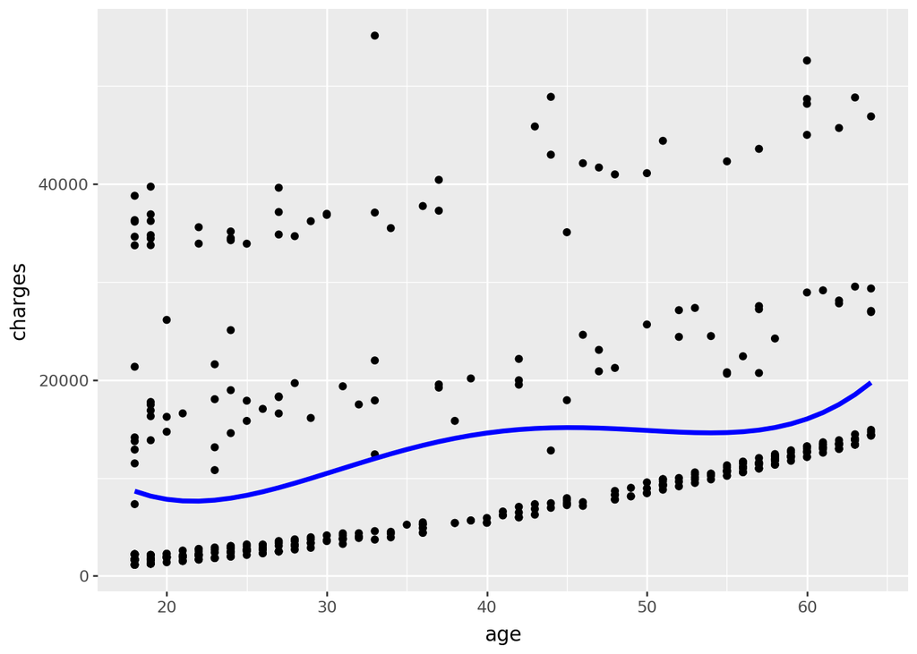

```python
df['predicted_for_x4'] = y_pred_lrfit_test_for_prob6
(ggplot(df,
aes(x = 'age', y = 'charges'))
+ geom_point()
+ geom_line(aes(y = 'predicted_for_x4'), size= 1.5, color = 'blue')
)
```

## 4

# Loading Data

```python
new_dat = pd.read_csv('https://www.dropbox.com/s/sky86agc4s8c6qe/insurance_costs_2.csv?dl=1')
```

# Cleaning

```python
new_df = get_dummies(new_dat)
```

# Models

Age only

```python
y = df['charges']
X = df[['age']]

lr_fit_age = lr.fit(X, y)

pred_age = lr_fit_age.predict(new_df[['age']])
mse_test_age = mean_squared_error(new_df['charges'], pred_age)


print(f'The MSE for the model including age is {round(mse_test_age,2)}.')
```

```
The MSE for the model including age is 136077136.5.
```

Age, bmi

```python
yy = df['charges']
XX = df[['age', 'bmi']]

lr_fit_age_bmi = lr.fit(XX, yy)

pred_age_bmi = lr_fit_age_bmi.predict(new_df[['age','bmi']])
mse_test_age_bmi = mean_squared_error(new_df['charges'], pred_age_bmi)


print(f'The MSE for the model including age and bmi is {round(mse_test_age_bmi,2)}.')
```

```
The MSE for the model including age and bmi is 132636406.11.
```

Age, bmi, smoke

```python
yyy = df['charges']
XXX = df[['age', 'bmi', 'smoker_yes']]

lr_fit_abs = lr.fit(XXX, yyy)

y_pred_lrfit_test_smoke = lr_fit_abs.predict(new_df[['age','bmi','smoker_yes']])

mse_test_lrfit_smoke = mean_squared_error(new_df['charges'], y_pred_lrfit_test_smoke)

print(f'The MSE for the model including age bmi and smoker is {round(mse_test_lrfit_smoke,2)}.')
```

```
The MSE for the model including age bmi and smoker is 35377541.24.
```

Age, bmi, smoke interactions

```python
df['age_smoke'] = df['age'] * df['smoker_yes']
df['bmi_smoke'] = df['bmi'] * df['smoker_yes']

new_df['age_smoke'] = new_df['age'] * new_df['smoker_yes']
new_df['bmi_smoke'] = new_df['bmi'] * new_df['smoker_yes']
```

```python
y_s_i = df['charges']
X_s_i = df[['age', 'bmi', 'age_smoke', 'bmi_smoke']]

lr_fit_si = lr.fit(X_s_i, y_s_i)

y_pred_lrfit_test_si = lr_fit.predict(new_df[['age','bmi','age_smoke', 'bmi_smoke']])

mse_test_lrfit_smoke = mean_squared_error(new_df['charges'], y_pred_lrfit_test_si)

print(f'The MSE for the model including age, bmi, and interactions between age/smoker and bmi/smoker is {round(mse_test_lrfit_smoke,2)}.')
```

```
The MSE for the model including age, bmi, and interactions between age/smoker and bmi/smoker is 24795908.41.
```

Age, bmi, smoker, smoker interactions

```python
y_s_i2 = df['charges']
X_s_i2 = df[['age', 'bmi', 'smoker_yes', 'age_smoke', 'bmi_smoke']]

lr_fit_si2 = lr.fit(X_s_i2, y_s_i2)

y_pred_lrfit_test_si2 = lr_fit2.predict(new_df[['age','bmi', 'smoker_yes','age_smoke', 'bmi_smoke']])
# putting the predicted on the dataset
new_df['predicted_charges'] = lr_fit2.predict(new_df[['age','bmi', 'smoker_yes','age_smoke', 'bmi_smoke']])

mse_test_lrfit_si2 = mean_squared_error(new_df['charges'], y_pred_lrfit_test_si2)

print(f'The MSE for the model including age, bmi, smoker and interactions between age/smoker and bmi/smoker is {round(mse_test_lrfit_si2,2)}.')
```

```
The MSE for the model including age, bmi, smoker and interactions between age/smoker and bmi/smoker is 21786256.87.
```

Based on the MSE’s of all the models, the model with the smallest MSE that seems to be the best fit is the model containing `age`, `bmi`, `smoker`, `age*smoke`, and `bmi*smoke`.

# Residuals

```python
new_df['residuals'] = new_df['charges'] - new_df['predicted_charges']
```

# Plot

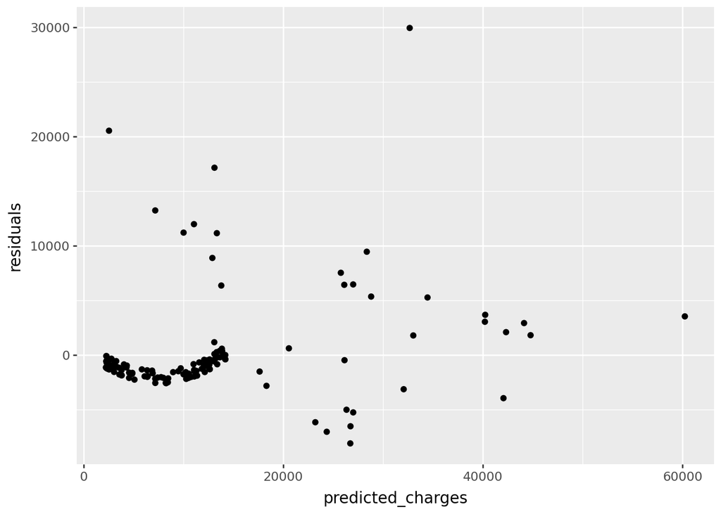

```python
(ggplot(new_df,
aes(x = 'predicted_charges', y = 'residuals'))
+ geom_point()
)
```

I’m fairly accurate this graph is representative of the data and that my code is correct…but I’m not sure what to make of it, especially with that strange grouping of residuals.

## 5

```python
df['bmi2'] = df['bmi'] ** 2
df['bmi3'] = df['bmi'] ** 3
df['bmi4'] = df['bmi'] ** 4
df['bmi5'] = df['bmi'] ** 5
df['bmi6'] = df['bmi'] ** 6
df['bmi7'] = df['bmi'] ** 7
df['bmi8'] = df['bmi'] ** 8


new_df['bmi2'] = new_df['bmi'] ** 2
new_df['bmi3'] = new_df['bmi'] ** 3
new_df['bmi4'] = new_df['bmi'] ** 4
new_df['bmi5'] = new_df['bmi'] ** 5
new_df['bmi6'] = new_df['bmi'] ** 6
new_df['bmi7'] = new_df['bmi'] ** 7
new_df['bmi8'] = new_df['bmi'] ** 8
```

Base model, no polynomials

```python
y_bmi = df['charges']
X_bmi = df[['age', 'bmi', 'smoker_yes']]

lr_fit_bmi = lr.fit(X_bmi, y_bmi)

y_pred_lrfit_test_bmi = lr_fit_bmi.predict(new_df[['age','bmi','smoker_yes']])

mse_test_lrfit_bmi = mean_squared_error(new_df['charges'], y_pred_lrfit_test_bmi)

print(f'The MSE for the model including age bmi and smoker is {round(mse_test_lrfit_bmi,2)}.')
```

```
The MSE for the model including age bmi and smoker is 35377541.24.
```

bmi^2

```python
y_bmi2 = df['charges']
X_bmi2 = df[['age', 'bmi', 'bmi2', 'smoker_yes']]

lr_fit_bmi2 = lr.fit(X_bmi2, y_bmi2)

y_pred_lrfit_test_bmi2 = lr_fit_bmi2.predict(new_df[['age','bmi', 'bmi2','smoker_yes']])

mse_test_lrfit_bmi2 = mean_squared_error(new_df['charges'], y_pred_lrfit_test_bmi2)

print(f'The MSE for the model including age bmi and smoker is {round(mse_test_lrfit_bmi2,2)}.')
```

```
The MSE for the model including age bmi and smoker is 35358468.75.
```

```python
y_bmi4 = df['charges']
X_bmi4 = df[['age', 'bmi', 'bmi2', 'bmi3', 'bmi4', 'smoker_yes']]

lr_fit_bmi4 = lr.fit(X_bmi4, y_bmi4)

y_pred_lrfit_test_bmi4 = lr_fit_bmi4.predict(new_df[['age','bmi', 'bmi2','bmi3', 'bmi4','smoker_yes']])

mse_test_lrfit_bmi4 = mean_squared_error(new_df['charges'], y_pred_lrfit_test_bmi4)

print(f'The MSE for the model including age bmi and smoker is {round(mse_test_lrfit_bmi4,2)}.')
```

```
The MSE for the model including age bmi and smoker is 35763406.62.
```

Bmi^8

```python
y_bmi8 = df['charges']
X_bmi8 = df[['age', 'bmi', 'bmi2', 'bmi3', 'bmi4', 'bmi5', 'bmi6', 'bmi7', 'bmi8', 'smoker_yes']]

lr_fit_bmi8 = lr.fit(X_bmi8, y_bmi8)

y_pred_lrfit_test_bmi8 = lr_fit_bmi8.predict(new_df[['age','bmi', 'bmi2','bmi3', 'bmi4', 'bmi5', 'bmi6', 'bmi7', 'bmi8','smoker_yes']])

mse_test_lrfit_bmi8 = mean_squared_error(new_df['charges'], y_pred_lrfit_test_bmi8)

print(f'The MSE for the model including age bmi and smoker is {round(mse_test_lrfit_bmi8,2)}.')
```

```
The MSE for the model including age bmi and smoker is 109690692.0.
```

From those models, bmi^2 gave the lowest mse so we’ll use that going forward

Interaction between smoker and age

```python
y_int = df['charges']
X_int = df[['age', 'bmi', 'bmi2', 'smoker_yes', 'age_smoke']]

lr_fit_int = lr.fit(X_int, y_int)

y_pred_lrfit_test_int = lr_fit_int.predict(new_df[['age','bmi', 'bmi2','smoker_yes', 'age_smoke']])

mse_test_lrfit_int = mean_squared_error(new_df['charges'], y_pred_lrfit_test_int)

print(f'The MSE for the model including age bmi and smoker is {round(mse_test_lrfit_int,2)}.')
```

```
The MSE for the model including age bmi and smoker is 35463097.41.
```

```python
y_int_sex = df['charges']
X_int_sex = df[['age', 'bmi', 'bmi2', 'smoker_yes', 'age_smoke', 'sex_male']]

lr_fit_int_sex = lr.fit(X_int_sex, y_int_sex)

y_pred_lrfit_test_int_sex = lr_fit_int_sex.predict(new_df[['age','bmi', 'bmi2','smoker_yes', 'age_smoke', 'sex_male']])

mse_test_lrfit_int_sex = mean_squared_error(new_df['charges'], y_pred_lrfit_test_int_sex)

print(f'The MSE for the model including age bmi and smoker is {round(mse_test_lrfit_int_sex,2)}.')
```

```
The MSE for the model including age bmi and smoker is 35562925.32.
```

MSE went back up so we’re not going to include sex in the model

Putting bmi interaction with smoker in the model.

```python
y_w = df['charges']
X_w = df[['age', 'bmi', 'bmi2', 'smoker_yes', 'age_smoke',  'bmi_smoke']]

lr_fit_int_w = lr.fit(X_w, y_w)

y_pred_lrfit_test_w = lr_fit_int_w.predict(new_df[['age','bmi', 'bmi2','smoker_yes', 'age_smoke', 'bmi_smoke']])
# putting prediction in dataset
new_df['predicted_charges2'] = lr_fit_int_w.predict(new_df[['age','bmi', 'bmi2','smoker_yes', 'age_smoke', 'bmi_smoke']])

mse_test_lrfit_w = mean_squared_error(new_df['charges'], y_pred_lrfit_test_w)

print(f'The MSE for the model including age bmi and smoker is {round(mse_test_lrfit_w)}.')
```

```
The MSE for the model including age bmi and smoker is 21640477.
```

Winner winner chicken dinner!!! Found that the model containing `age`, `bmi`, `bmi2`, `smoker_yes`, `age*smoke`, `bmi*smoke` brought the smallest MSE and would be the best fit for the new data.

# Residuals

```python
# putting the predicted on the dataset


new_df['residuals2'] = new_df['charges'] - new_df['predicted_charges2']
```

# Plot

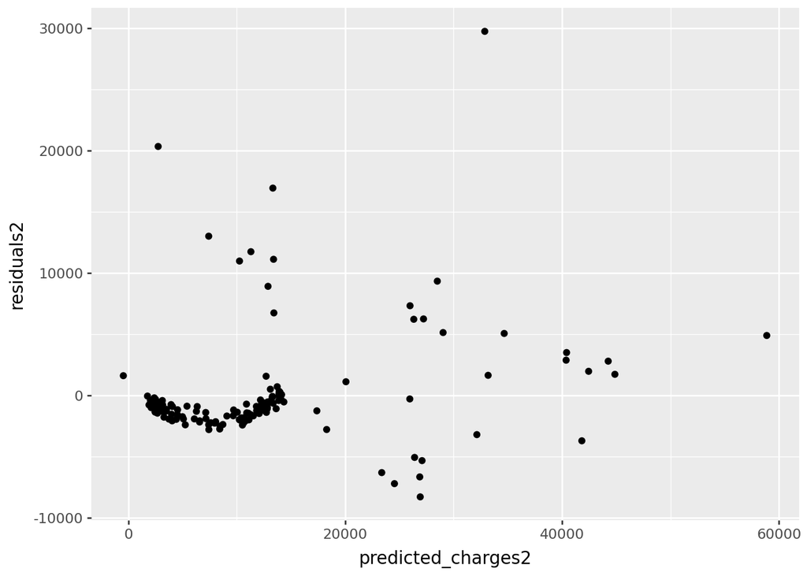

```python
(ggplot(new_df,
aes(x = 'predicted_charges2', y = 'residuals2'))
+ geom_point()
)
```

This plot doesn’t look very different from the plot constructed in the previous problem.